# Analisis de Supuestos Estadisticos

**Escala de Empatia (Empathy Quotient, EQ-10)**

Como primera etapa en el analisis de datos de la validacion de la escala de empatia, realizaremos graficas y estadisticos descriptivos para cada uno de los items individuales como para la escala en su conjunto. Principalmente nos centraremos en examinar si la escala cumple con los supuestos de normalidad univariantes y multivariante. Para esto, utilizaremos librerias de R que nos entrega las graficas (ggplot2), estadisticos descriptivos (pastecs) y los valores para decidir si la escala esta multivariamente distribuida (MVN).

Cargar la base de datos desde GitHub

```r
library (readr)
urlfile="https://raw.githubusercontent.com/danielivanperez/base_de_datos_empatia-09.01.2022-/main/base_de_datos_empatia_n_645_modificados_y_subdimensiones_(20.01.2022).csv"

datos_empatia<-read_csv(url(urlfile))
```

Revisar Supuestos de los items de la Escala de Empatia

1. Supuesto de Normalidad Univariante y Multivariante

**1.1Normalidad Univariante**

Para mas info ver link: http://gide.unileon.es/admin/UploadFolder/covarianzas.pdf

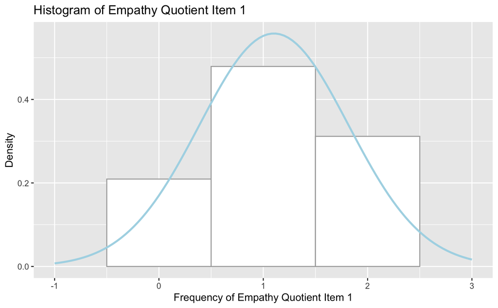

```r
# Check if assumption of multivariate normality is met
    # 1. histograms

# emp_1
library(ggplot2)
ggplot(datos_empatia, aes(emp_1))+
  geom_histogram(aes(y=..density..), binwidth = 1, color="darkgrey", fill = "white")+
  labs(x="Frequency of Empathy Quotient Item 1", y= "Density", title = "Histogram of Empathy Quotient Item 1")+
  stat_function(fun = dnorm,args = list(mean=mean(datos_empatia$emp_1,na.rm = TRUE), sd = sd(datos_empatia$emp_1,na.rm = TRUE)),color="lightblue",size=1)+
  xlim(-1,3)
```

```r
library(pastecs)
stat.desc(datos_empatia$emp_1)
```

```
     nbr.val     nbr.null       nbr.na          min          max        range          sum       median
645.00000000 135.00000000   0.00000000   0.00000000   2.00000000   2.00000000 711.00000000   1.00000000
        mean      SE.mean CI.mean.0.95          var      std.dev     coef.var
  1.10232558   0.02815385   0.05528443   0.51125235   0.71501912   0.64864604
```

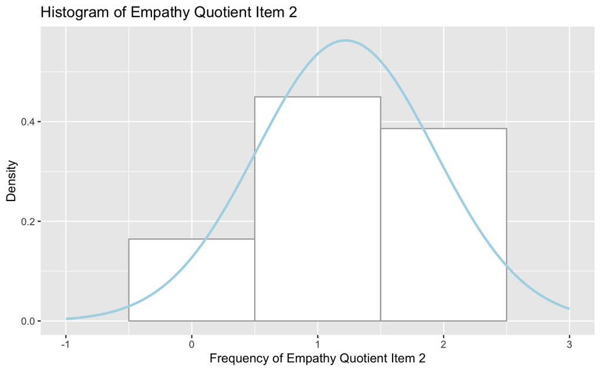

```r
# emp_2
library(ggplot2)
ggplot(datos_empatia, aes(emp_2))+
  geom_histogram(aes(y=..density..), binwidth = 1, color="darkgrey", fill = "white")+
  labs(x="Frequency of Empathy Quotient Item 2", y= "Density", title = "Histogram of Empathy Quotient Item 2")+
  stat_function(fun = dnorm,args = list(mean=mean(datos_empatia$emp_2,na.rm = TRUE), sd = sd(datos_empatia$emp_2,na.rm = TRUE)),color="lightblue",size=1)+
  xlim(-1,3)
```

```r
library(pastecs)
stat.desc(datos_empatia$emp_2)
```

```
     nbr.val     nbr.null       nbr.na          min          max        range          sum       median
645.00000000 106.00000000   0.00000000   0.00000000   2.00000000   2.00000000 788.00000000   1.00000000
        mean      SE.mean CI.mean.0.95          var      std.dev     coef.var
  1.22170543   0.02789828   0.05478259   0.50201261   0.70852849   0.57995035
```

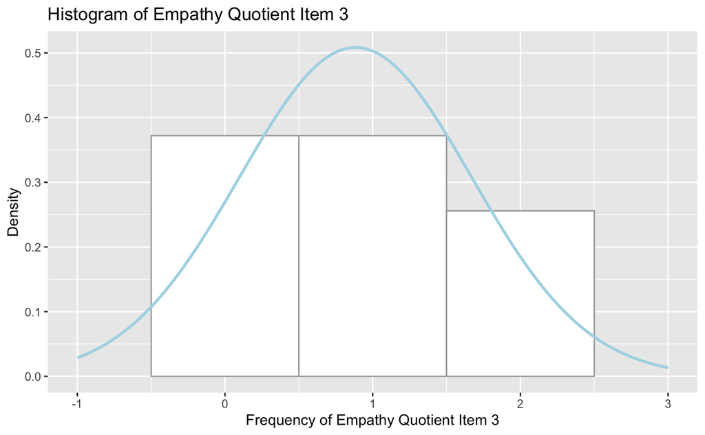

```r
# emp_3
library(ggplot2)
ggplot(datos_empatia, aes(emp_3))+
  geom_histogram(aes(y=..density..), binwidth = 1, color="darkgrey", fill = "white")+
  labs(x="Frequency of Empathy Quotient Item 3", y= "Density", title = "Histogram of Empathy Quotient Item 3")+
  stat_function(fun = dnorm,args = list(mean=mean(datos_empatia$emp_3,na.rm = TRUE), sd = sd(datos_empatia$emp_3,na.rm = TRUE)),color="lightblue",size=1)+
  xlim(-1,3)
```

```r
stat.desc(datos_empatia$emp_3)
```

```
     nbr.val     nbr.null       nbr.na          min          max        range          sum       median
645.00000000 240.00000000   0.00000000   0.00000000   2.00000000   2.00000000 570.00000000   1.00000000
        mean      SE.mean CI.mean.0.95          var      std.dev     coef.var
  0.88372093   0.03088715   0.06065168   0.61534017   0.78443621   0.88765150
```

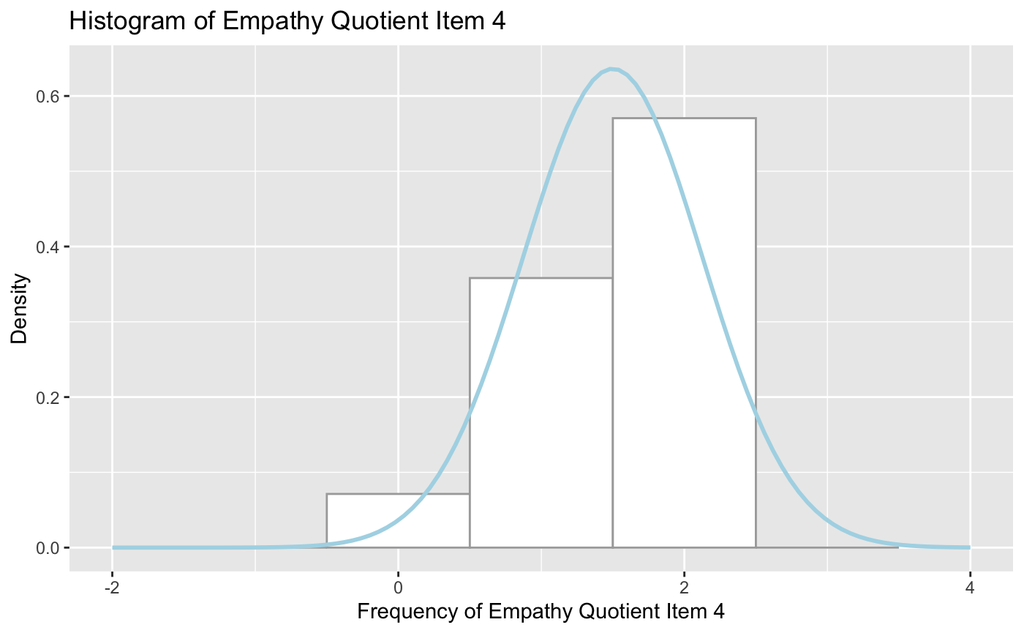

```r
# emp_4
library(ggplot2)
ggplot(datos_empatia, aes(emp_4))+
  geom_histogram(aes(y=..density..), binwidth = 1, color="darkgrey", fill = "white")+
  labs(x="Frequency of Empathy Quotient Item 4", y= "Density", title = "Histogram of Empathy Quotient Item 4")+
  stat_function(fun = dnorm,args = list(mean=mean(datos_empatia$emp_4,na.rm = TRUE), sd = sd(datos_empatia$emp_4,na.rm = TRUE)),color="lightblue",size=1)+
  xlim(-2,4)
```

```r
stat.desc(datos_empatia$emp_4)
```

```
     nbr.val     nbr.null       nbr.na          min          max        range          sum       median
645.00000000  46.00000000   0.00000000   0.00000000   2.00000000   2.00000000 967.00000000   2.00000000
        mean      SE.mean CI.mean.0.95          var      std.dev     coef.var
  1.49922481   0.02469173   0.04848603   0.39324474   0.62709229   0.41827769
```

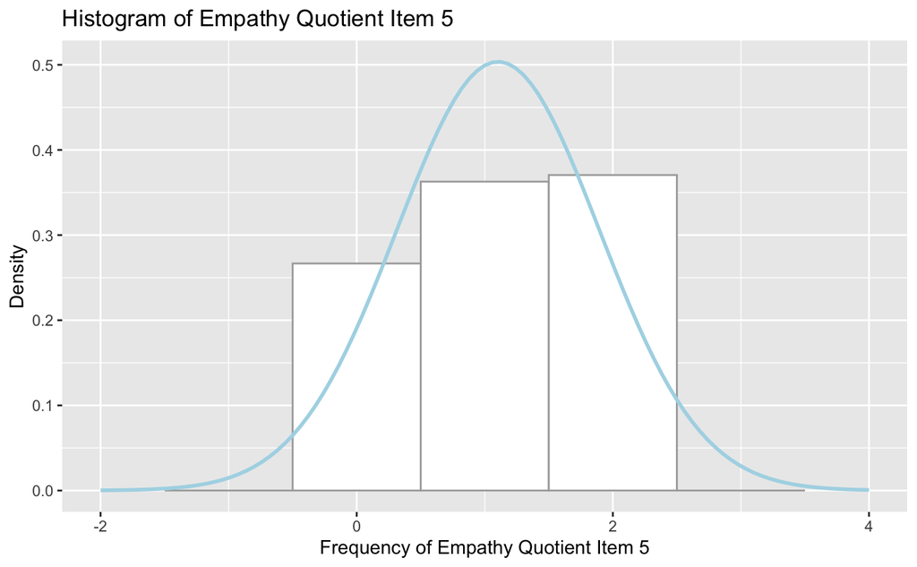

```r
# emp_5
library(ggplot2)
ggplot(datos_empatia, aes(emp_5))+
  geom_histogram(aes(y=..density..), binwidth = 1, color="darkgrey", fill = "white")+
  labs(x="Frequency of Empathy Quotient Item 5", y= "Density", title = "Histogram of Empathy Quotient Item 5")+
  stat_function(fun = dnorm,args = list(mean=mean(datos_empatia$emp_5,na.rm = TRUE), sd = sd(datos_empatia$emp_5,na.rm = TRUE)),color="lightblue",size=1)+
  xlim(-2,4)
```

```r
stat.desc(datos_empatia$emp_5)
```

```
     nbr.val     nbr.null       nbr.na          min          max        range          sum       median
645.00000000 172.00000000   0.00000000   0.00000000   2.00000000   2.00000000 712.00000000   1.00000000
        mean      SE.mean CI.mean.0.95          var      std.dev     coef.var
  1.10387597   0.03118815   0.06124274   0.62739179   0.79208067   0.71754499
```

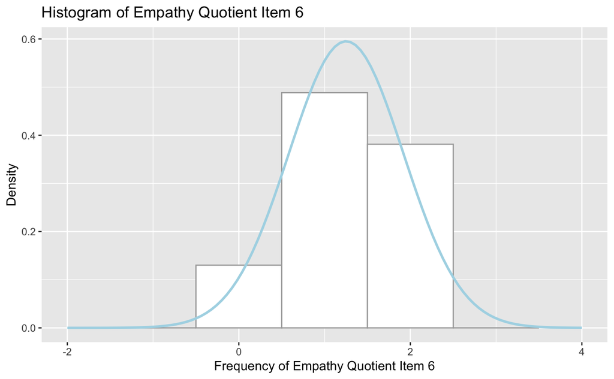

```r
# emp_6
library(ggplot2)
ggplot(datos_empatia, aes(emp_6))+
  geom_histogram(aes(y=..density..), binwidth = 1, color="darkgrey", fill = "white")+
  labs(x="Frequency of Empathy Quotient Item 6", y= "Density", title = "Histogram of Empathy Quotient Item 6")+
  stat_function(fun = dnorm,args = list(mean=mean(datos_empatia$emp_6,na.rm = TRUE), sd = sd(datos_empatia$emp_6,na.rm = TRUE)),color="lightblue",size=1)+
  xlim(-2,4)
```

```r
stat.desc(datos_empatia$emp_6)
```

```
     nbr.val     nbr.null       nbr.na          min          max        range          sum       median
645.00000000  84.00000000   0.00000000   0.00000000   2.00000000   2.00000000 807.00000000   1.00000000
        mean      SE.mean CI.mean.0.95          var      std.dev     coef.var
  1.25116279   0.02639126   0.05182332   0.44924166   0.67025492   0.53570561
```

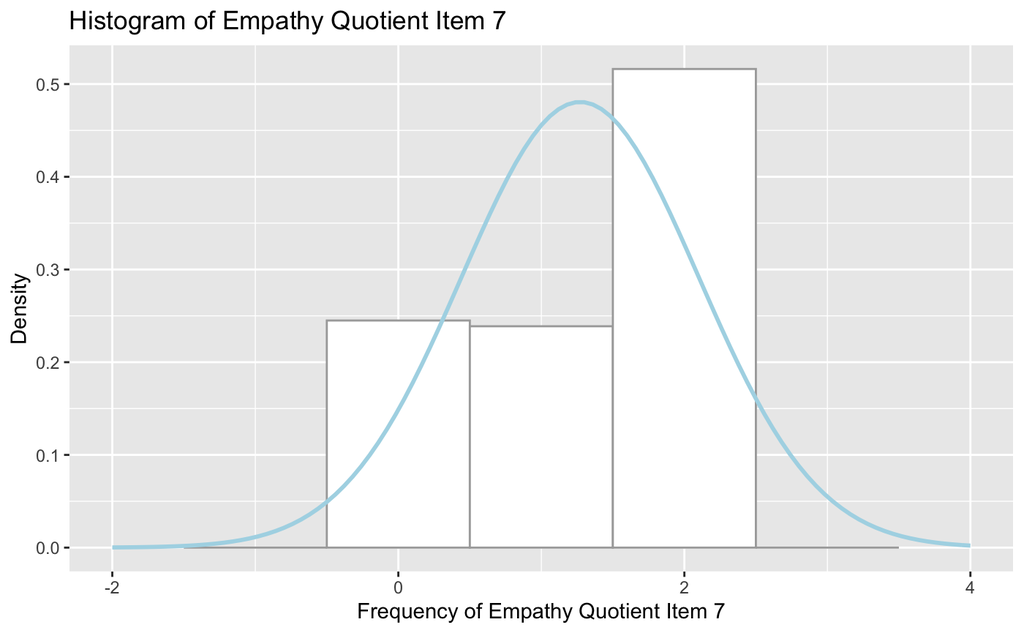

```r
# emp_7
library(ggplot2)
ggplot(datos_empatia, aes(emp_7))+
  geom_histogram(aes(y=..density..), binwidth = 1, color="darkgrey", fill = "white")+
  labs(x="Frequency of Empathy Quotient Item 7", y= "Density", title = "Histogram of Empathy Quotient Item 7")+
  stat_function(fun = dnorm,args = list(mean=mean(datos_empatia$emp_7,na.rm = TRUE), sd = sd(datos_empatia$emp_7,na.rm = TRUE)),color="lightblue",size=1)+
  xlim(-2,4)
```

```r
stat.desc(datos_empatia$emp_7)
```

```
     nbr.val     nbr.null       nbr.na          min          max        range          sum       median
645.00000000 158.00000000   0.00000000   0.00000000   2.00000000   2.00000000 820.00000000   2.00000000
        mean      SE.mean CI.mean.0.95          var      std.dev     coef.var
  1.27131783   0.03267635   0.06416506   0.68869469   0.82987631   0.65276856
```

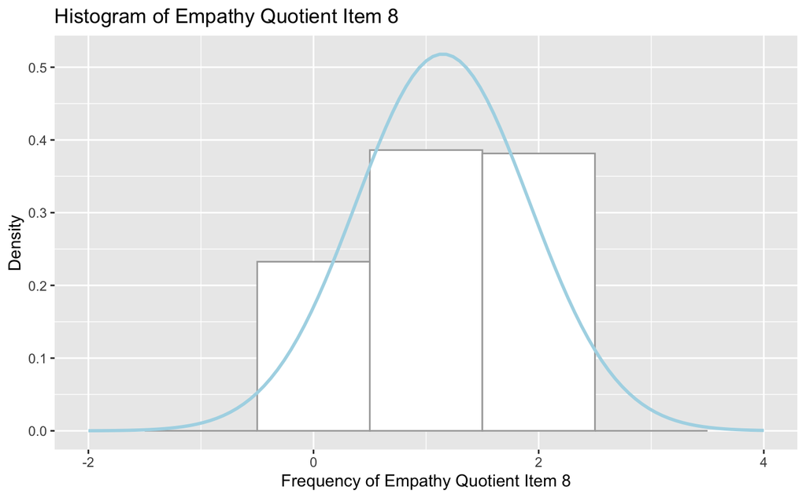

```r
# emp_8
library(ggplot2)
ggplot(datos_empatia, aes(emp_8))+
  geom_histogram(aes(y=..density..), binwidth = 1, color="darkgrey", fill = "white")+
  labs(x="Frequency of Empathy Quotient Item 8", y= "Density", title = "Histogram of Empathy Quotient Item 8")+
  stat_function(fun = dnorm,args = list(mean=mean(datos_empatia$emp_8,na.rm = TRUE), sd = sd(datos_empatia$emp_8,na.rm = TRUE)),color="lightblue",size=1)+
  xlim(-2,4)
```

```r
stat.desc(datos_empatia$emp_8)
```

```
     nbr.val     nbr.null       nbr.na          min          max        range          sum       median
645.00000000 150.00000000   0.00000000   0.00000000   2.00000000   2.00000000 741.00000000   1.00000000
        mean      SE.mean CI.mean.0.95          var      std.dev     coef.var
  1.14883721   0.03031412   0.05952645   0.59271992   0.76988306   0.67014112
```

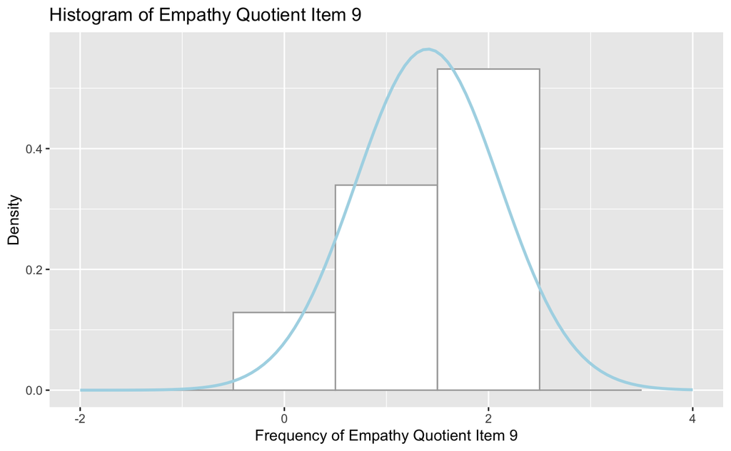

```r
# emp_9
library(ggplot2)
ggplot(datos_empatia, aes(emp_9))+
  geom_histogram(aes(y=..density..), binwidth = 1, color="darkgrey", fill = "white")+
  labs(x="Frequency of Empathy Quotient Item 9", y= "Density", title = "Histogram of Empathy Quotient Item 9")+
  stat_function(fun = dnorm,args = list(mean=mean(datos_empatia$emp_9,na.rm = TRUE), sd = sd(datos_empatia$emp_9,na.rm = TRUE)),color="lightblue",size=1)+
  xlim(-2,4)
```

```r
stat.desc(datos_empatia$emp_9)
```

```
     nbr.val     nbr.null       nbr.na          min          max        range          sum       median
645.00000000  83.00000000   0.00000000   0.00000000   2.00000000   2.00000000 905.00000000   2.00000000
        mean      SE.mean CI.mean.0.95          var      std.dev     coef.var
  1.40310078   0.02780743   0.05460418   0.49874813   0.70622102   0.50332880
```

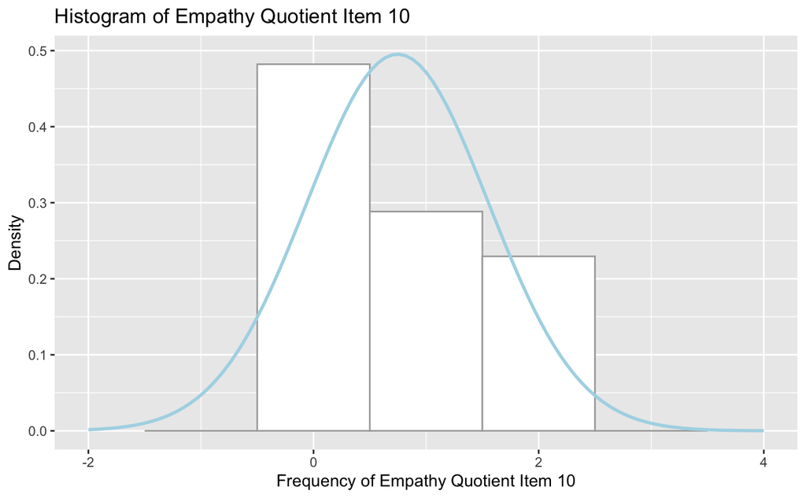

```r
# emp_10
library(ggplot2)
ggplot(datos_empatia, aes(emp_10))+
  geom_histogram(aes(y=..density..), binwidth = 1, color="darkgrey", fill = "white")+
  labs(x="Frequency of Empathy Quotient Item 10", y= "Density", title = "Histogram of Empathy Quotient Item 10")+
  stat_function(fun = dnorm,args = list(mean=mean(datos_empatia$emp_10,na.rm = TRUE), sd = sd(datos_empatia$emp_10,na.rm = TRUE)),color="lightblue",size=1)+
  xlim(-2,4)
```

```r
stat.desc(datos_empatia$emp_10)
```

```
     nbr.val     nbr.null       nbr.na          min          max        range          sum       median
645.00000000 311.00000000   0.00000000   0.00000000   2.00000000   2.00000000 482.00000000   1.00000000
        mean      SE.mean CI.mean.0.95          var      std.dev     coef.var
  0.74728682   0.03171505   0.06227741   0.64876980   0.80546248   1.07784916
```

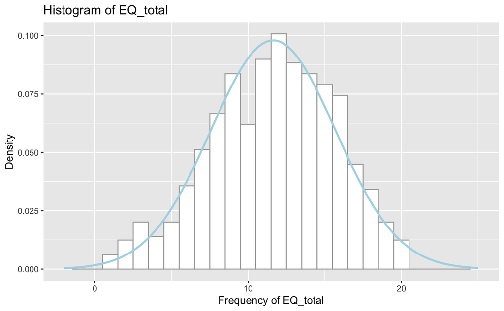

```r
# EQ_TOTAL
library(ggplot2)
ggplot(datos_empatia, aes(EQ_total))+
  geom_histogram(aes(y=..density..), binwidth = 1, color="darkgrey", fill = "white")+
  labs(x="Frequency of EQ_total", y= "Density", title = "Histogram of EQ_total")+
  stat_function(fun = dnorm,args = list(mean=mean(datos_empatia$EQ_total,na.rm = TRUE), sd = sd(datos_empatia$EQ_total,na.rm = TRUE)),color="lightblue",size=1)+
  xlim(-2,25)
```

```r
library(pastecs)
stat.desc(datos_empatia$EQ_total)
```

```
     nbr.val     nbr.null       nbr.na          min          max        range          sum       median
 645.0000000    0.0000000    0.0000000    1.0000000   20.0000000   19.0000000 7503.0000000   12.0000000
        mean      SE.mean CI.mean.0.95          var      std.dev     coef.var
  11.6325581    0.1603021    0.3147779   16.5744042    4.0711674    0.3499804
```

**1.2 Normalidad Multivariante**

Otro supuesto importante de testear es la normalidad multivariante, el cual puede ser implementado con la libreria MVN, utilizando el test de Mardia. Abajo la explicacion extraida de la libreria.

It computes Mardia (1970)’s multivariate skewness and kurtosis statistics and their corresponding p-value. Both p-values of skewness and kurtosis statistics **should be greater than 0.05 to conclude multivariate normality**. The skewness statistic will be adjusted for sample size n < 20.

```r
library("MVN")
#result_sqr <-

mvn(data = datos_empatia[,16:25],  mvnTest = "mardia")
```

| Test | Statistic | p value | Result |
| --- | --- | --- | --- |
| Mardia Skewness | 513.368698510562 | 1.6840717516954e-25 | NO |
| Mardia Kurtosis | -1.01626615557847 | 0.309502660653834 | YES |
| MVN | NA | NA | NO |

|  | Test | Variable | Statistic | p value | Normality |
| --- | --- | --- | --- | --- | --- |
| 1 | Anderson-Darling | emp_1 | 53.1836 | <0.001 | NO |
| 2 | Anderson-Darling | emp_2 | 56.8585 | <0.001 | NO |
| 3 | Anderson-Darling | emp_3 | 52.2703 | <0.001 | NO |
| 4 | Anderson-Darling | emp_4 | 84.2026 | <0.001 | NO |
| 5 | Anderson-Darling | emp_5 | 52.3163 | <0.001 | NO |
| 6 | Anderson-Darling | emp_6 | 61.4922 | <0.001 | NO |
| 7 | Anderson-Darling | emp_7 | 71.8069 | <0.001 | NO |
| 8 | Anderson-Darling | emp_8 | 52.8970 | <0.001 | NO |
| 9 | Anderson-Darling | emp_9 | 72.1869 | <0.001 | NO |
| 10 | Anderson-Darling | emp_10 | 64.3060 | <0.001 | NO |

|  | n | Mean | Std.Dev | Median | Min | Max | 25th | 75th | Skew | Kurtosis |
| --- | --- | --- | --- | --- | --- | --- | --- | --- | --- | --- |
| emp_1 | 645 | 1.1023256 | 0.7150191 | 1 | 0 | 2 | 1 | 2 | -0.1516736 | -1.0432790 |
| emp_2 | 645 | 1.2217054 | 0.7085285 | 1 | 0 | 2 | 1 | 2 | -0.3446010 | -0.9809015 |
| emp_3 | 645 | 0.8837209 | 0.7844362 | 1 | 0 | 2 | 0 | 2 | 0.2063702 | -1.3514464 |
| emp_4 | 645 | 1.4992248 | 0.6270923 | 2 | 0 | 2 | 1 | 2 | -0.8646940 | -0.2942144 |
| emp_5 | 645 | 1.1038760 | 0.7920807 | 1 | 0 | 2 | 0 | 2 | -0.1860459 | -1.3868905 |
| emp_6 | 645 | 1.2511628 | 0.6702549 | 1 | 0 | 2 | 1 | 2 | -0.3409253 | -0.8148241 |
| emp_7 | 645 | 1.2713178 | 0.8298763 | 2 | 0 | 2 | 1 | 2 | -0.5395174 | -1.3412308 |
| emp_8 | 645 | 1.1488372 | 0.7698831 | 1 | 0 | 2 | 1 | 2 | -0.2601346 | -1.2765563 |
| emp_9 | 645 | 1.4031008 | 0.7062210 | 2 | 0 | 2 | 1 | 2 | -0.7512252 | -0.6875963 |
| emp_10 | 645 | 0.7472868 | 0.8054625 | 1 | 0 | 2 | 0 | 1 | 0.4870669 | -1.2974182 |

```
NA
```

**Conclusion**

Segun todos los resultados de la salida de arriba, los items individuales no son normales (Normalidad Univariante) y el test de Mardia dice que la escala de empatia no cumple con el supuesto de la normalidad multivariante. Esto significa que cuando calculemos los analisis factoriales confimartorios deberiamos tener en cuenta al momento de aplicar los estimadores.